# STUDY OF BUS PROFILE OF THE U.S.

Singh Kiran Arjun (PG190463), Avani Gajjar (PG190211), Sukanya Talukdar (PG191015)

**Introduction** This project looks into the US bus system and specifically bus stops and the location of Chicago city through R studio programming. The first part addresses the performance, safety, and other aspects of the country ’s bus services, while the second part is about spatial locations of public bus service stops in one of the cities of the US, Chicago.

**Problem statement:** To analyze the temporal dynamism of various bus profiles in the U.S. for topics related to performance, financial expenditure and safety.

**Methodology:** The method used to analyze this data is by generating readable graphs and creating an interactive dashboard. The data used is by Bureau of Transportation Statistics. The data was cleaned by removing the empty cells and removing cells with codes like N = data do not exist; R = revised; U = data are not available.

In order to start the analysis, the first step is to install packages like: rmarkdown, flexdashboard, tidyverse, dplyr, ggplot2, shiny, stringr, corrplot, rsconnect, readxl, xlsx

Functions of these packages:

1.rmarkdown: helps you create dynamic analysis documents that combine code, rendered output (such as figures), and prose.

2.flexdashboard: used to publish groups of related data visualizations as a dashboard.

3.tidyverse: used as an umbrella to help us in performing and interacting with the data. There are a whole host of things you can do with your data, such as subsetting, transforming, visualizing, etc

4.dplyr: aims to provide a function for each basic verb of data manipulation.

5.ggplot2: how to map variables to aesthetics, what graphical primitives to use, and it takes care of the details.

6.shiny: Shiny is an R package that makes it easy to build interactive web apps straight from R.

7.stringr: stringr focuses on the most important and commonly used string manipulation functions whereas stringi provides a comprehensive set covering almost anything you can imagine.

8.corrplot: is for visualizing correlation matrices and confidence intervals.

9.rsconnect: Deployment Interface for R Markdown Documents and Shiny Applications.

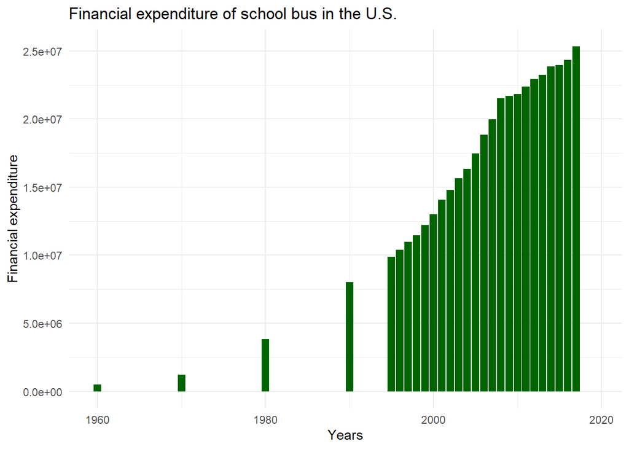

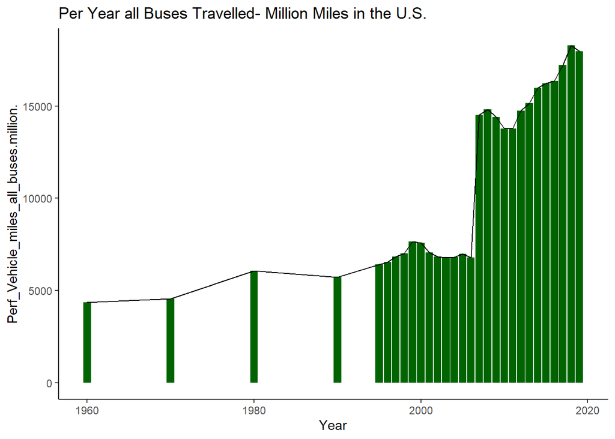

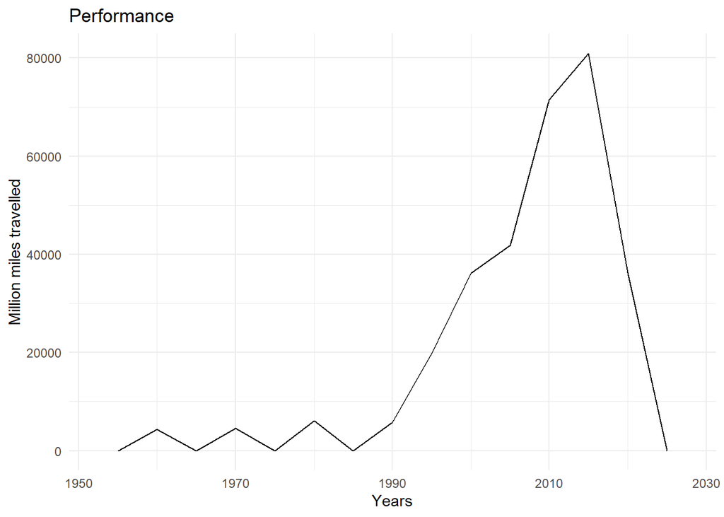

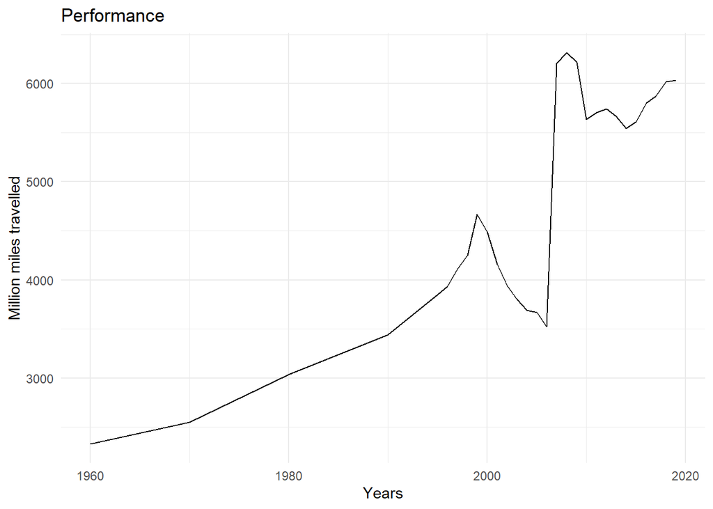

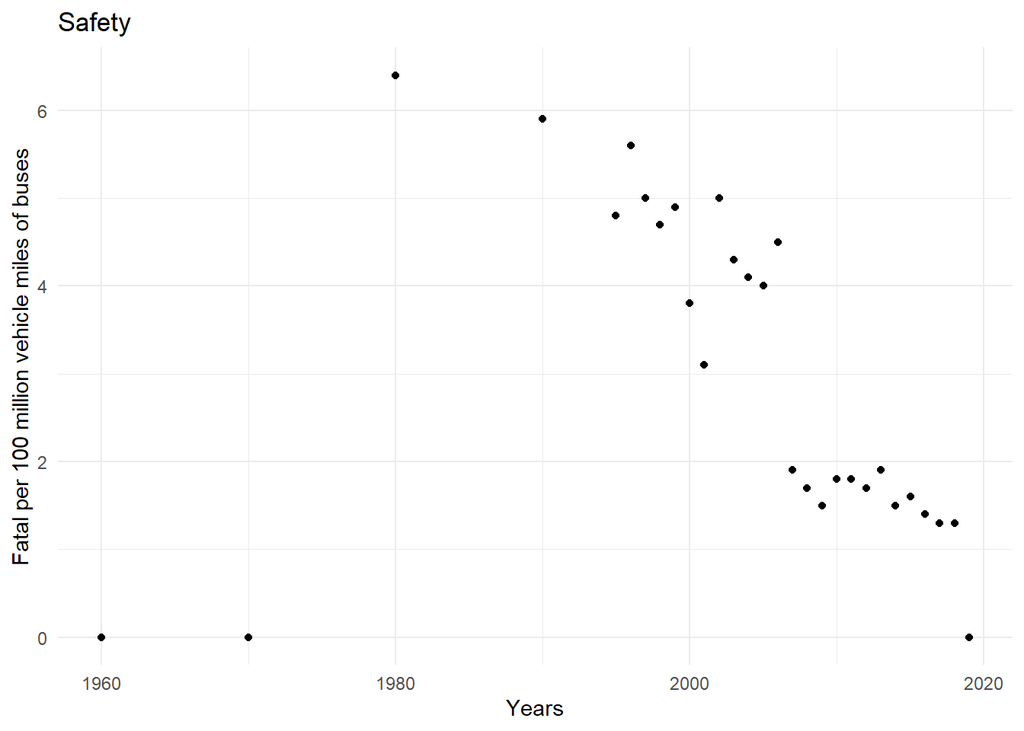

[output not shown]

[figure not shown]

[figure not shown]

**PART_2_Location of public bus services in chicago city** The geolocations of the public bus stops in the city of chicago is marked on city map through CSV data base through leaflet method. Geo locations of public bus stops in chicago city

|  | Stop_ID | CTA.Stop.Name | Direction | Routes | Ward | LONGITUDE | LATITUDE | Location | Phase |
| --- | --- | --- | --- | --- | --- | --- | --- | --- | --- |
| 1 | 68 | Jackson &amp; Franklin | EB | 1,7,28,126,130,151,156 | 42 | -87.635401 | 41.878051 | (41.878051, -87.635401) | 2 |
| 2 | 69 | Jackson &amp; Financial Place | EB | 1,7,28,126,130,132,151 | 42 | -87.632868 | 41.878081 | (41.878081, -87.632868) | 1 |
| 3 | 73 | Michigan &amp; Van Buren/Congress | SB | 1,3,4,7,J14,26,28,126,132,143,147 | 42 | -87.624396 | 41.876271 | (41.876271, -87.624396) | 1 |
| 4 | 75 | Michigan &amp; Van Buren | NB | 17,28,126 | 42 | -87.62416 | 41.87669 | (41.87669, -87.62416) | 2 |
| 5 | 76 | Michigan &amp; Jackson | NB | 3,4,6,J14,26,143 | 42 | -87.624193 | 41.878135 | (41.878135, -87.624193) | 1 |
| 6 | 77 | Adams &amp; Wabash | WB | 1,7,28,126,151 | 42 | -87.625884 | 41.879575 | (41.879575, -87.625884) | 2 |

[interactive chart not shown]